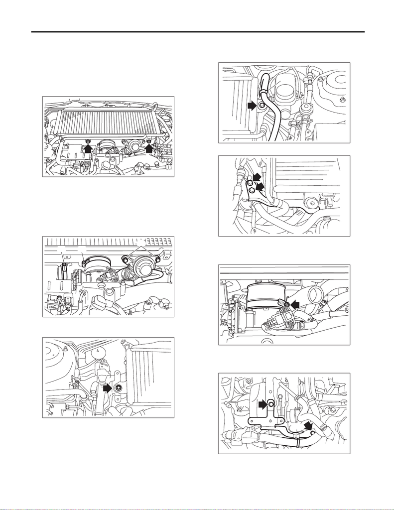

IN(STI)-13

Intercooler

INTAKE (INDUCTION)

6. Intercooler

A: REMOVAL

1) Remove the chamber assembly. <Ref. to

IN(STI)-22, REMOVAL, Chamber Assembly.>

2) Remove the bolts holding the PCV pipe to the in-

tercooler.

3) Loosen the clamp (A) holding the intake duct to

the turbocharger.

4) Loosen the clamp (B) holding the air duct hose

to the intercooler.

5) Remove the bolts (C) securing the air by-pass

valve to the intercooler, and disconnect the air by-

pass valve.

6) Remove the bolts which secure the intercooler to

the intercooler stay RH No. 1.

7) Remove the brake booster vacuum hose from

the intercooler clip (A), and remove the bolts which

secure the intercooler to the intercooler stay LH.

8) Remove the intercooler stay LH.

9) Remove the intercooler.

10) Remove the air duct hose from the throttle

body.

11) Remove clip (A) holding the engine harness to

the intercooler stay RH No. 1, and remove the inter-

cooler stay RH No. 1.

IN-03584

IN-03497

(A)

(B)

(C)

IN-03566

IN-03567

(A)

IN-03569

IN-03104

IN-03649

(A)

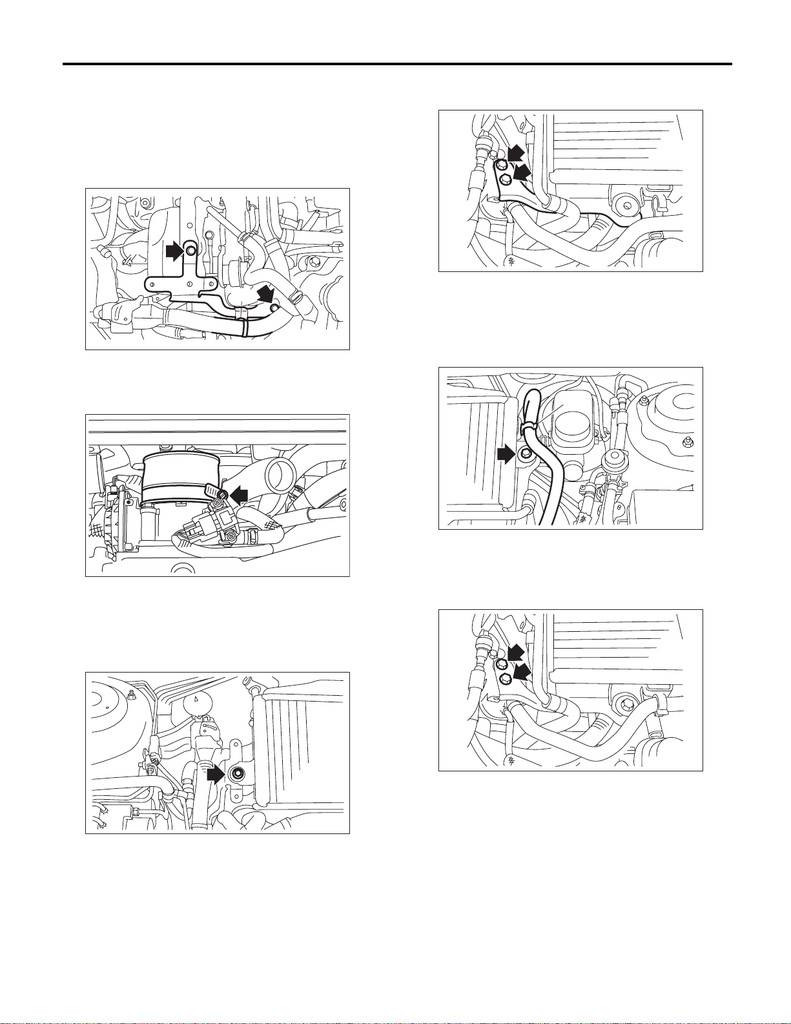

IN(STI)-14

Intercooler

INTAKE (INDUCTION)

B: INSTALLATION

1) Install the intercooler stay RH No. 1, and install

the clip (A) which secures the engine harness to

the intercooler stay RH No. 1.

Tightening torque:

16 N·m (1.6 kgf-m, 11.8 ft-lb)

2) Attach the air duct hose to the throttle body.

Tightening torque:

3 N·m (0.3 kgf-m, 2.2 ft-lb)

3) Set the intercooler to the vehicle, and install the

bolts securing the intercooler to the intercooler stay

RH No. 1.

Tightening torque:

16 N·m (1.6 kgf-m, 11.8 ft-lb)

4) Temporarily tighten the bolt securing the inter-

cooler stay LH to the intake manifold.

5) Install the bolts which secure the intercooler to

the intercooler stay LH, and install the brake boost-

er vacuum hose to the clip (A).

Tightening torque:

16 N·m (1.6 kgf-m, 11.8 ft-lb)

6) Tighten the bolt securing the intercooler stay LH

to the intake manifold.

Tightening torque:

16 N·m (1.6 kgf-m, 11.8 ft-lb)

7) Tighten the clamp (A) which secures the intake

duct to the turbocharger.

8) Tighten the clamp (B) which secures the air duct

hose to the intercooler.

IN-03649

(A)

IN-03104

IN-03566

IN-03569

IN-03567

(A)

IN-03650

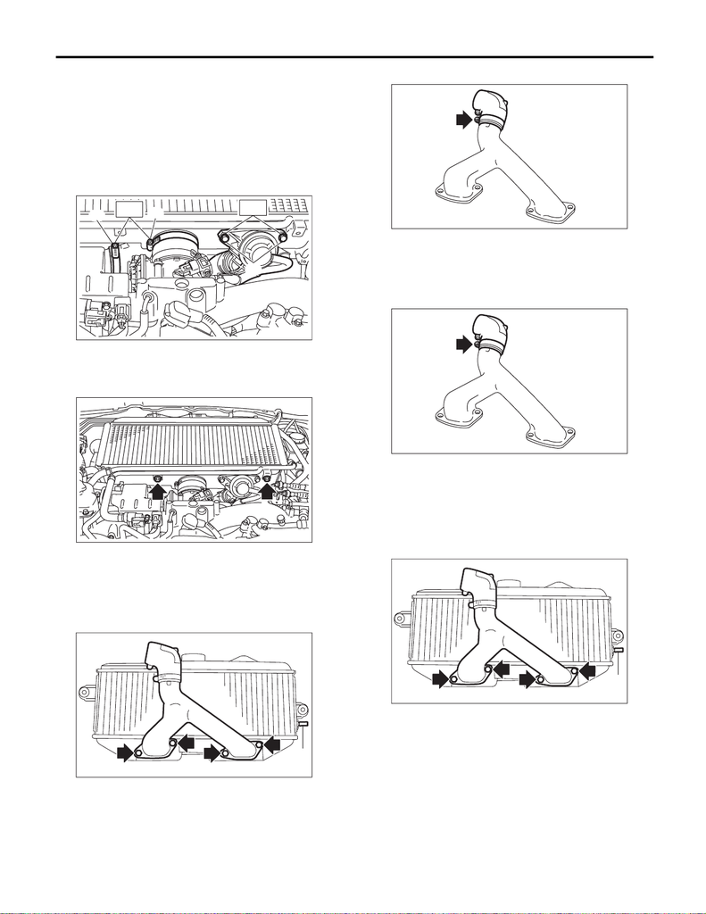

IN(STI)-15

Intercooler

INTAKE (INDUCTION)

9) Install the bolts (C) which secures the air by-

pass valve to the intercooler, and install the air by-

pass valve.

NOTE:

Use a new gasket.

Tightening torque:

T1: 3 N·m (0.3 kgf-m, 2.2 ft-lb)

T2: 16 N·m (1.6 kgf-m, 11.8 ft-lb)

10) Install the PCV pipe to the intercooler.

Tightening torque:

5.5 N·m (0.6 kgf-m, 4.1 ft-lb)

11) Install the chamber assembly. <Ref. to IN(STI)-

22, INSTALLATION, Chamber Assembly.>

C: DISASSEMBLY

1) Remove the clip (A) and intercooler duct from

the intercooler.

2) Remove the intake duct from intercooler duct.

D: ASSEMBLY

1) Install the intake duct to the intercooler duct.

Tightening torque:

3 N·m (0.3 kgf-m, 2.2 ft-lb)

2) Install the clip (A) and intercooler duct to the in-

tercooler.

NOTE:

Use a new gasket.

Tightening torque:

16 N·m (1.6 kgf-m, 11.8 ft-lb)

E: INSPECTION

1) Check that the intercooler and intercooler duct

have no deformation, cracks or other damages.

2) Check that the hose and intake duct have no

cracks, damage or loose part.

IN-03502

(A)

(B)

(C)

T1

T2

IN-03584

IN-03600

(A)

IN-02350

IN-02350

IN-03600

(A)